# L19: Language Complexity

Bogdan G. Popescu

bogdan.popescu@johncabot.edu

Tecnológico de Monterrey

## Complexity

One important aspect of text is the *complexity* of language used in a corpus of text.

On the most basic level, we can have a measure of linguistic diversity - **Type-to-Token Ratio** (TTR)

$$TTR = \frac{\textrm{Number of Types (V)}}{\textrm{Number of Tokens (N)}}$$

## Complexity

**Low Type-to-Token Ratio**

Example: “Democracy is the best system, the best system, the best system for governance.”

**High Type-to-Token Ratio**

Example: “Democracy is an excellent, effective, and universally admired system of governance.”

## Caveats associated with Complexity

Lexical diversity is sensitive to document length

Shorter texts display fewer word repetitions.

Longer texts may introduce additional subjects, which will include lexical richness.

## Implementation of Complexity: Flesch Reading Ease

We can use the `flesch_reading_ease` to calculate language complexity

```
Python
```

```python
import pandas as pd
from textstat import flesch_reading_ease

# Create a DataFrame with two sentences
df = pd.DataFrame({
    'text': [
        "Democracy is government of, by, and for the people.",
        "Democracy has multifaceted mechanisms to facilitate the distribution of power."
    ]})

# Calculate Flesch Reading Ease score
df['flesch_score'] = df['text'].apply(flesch_reading_ease)
```

| text | flesch_score |
| --- | --- |
| Democracy is government of, by, and for the people. | 62.34 |
| Democracy has multifaceted mechanisms to facilitate the distribution of power. | -6.36 |

## Complexity: Flesch Reading Ease

The Flesch Reading Ease is calculated as:

$$\text{Score} = 206.835 - 1.015 \left( \frac{\text{Total Words}}{\text{Total Sentences}} \right) - 84.6 \left( \frac{\text{Total Syllables}}{\text{Total Words}} \right)$$

$\text{Total Words}$: The total number of words in the text.

$\text{Total Sentences}$: The total number of sentences in the text.

$\text{Total Syllables}$: The total number of syllables in all words of the text.

$\frac{\text{Total Words}}{\text{Total Sentences}}$: The average sentence length.

$\frac{\text{Total Syllables}}{\text{Total Words}}$: The average number of syllables per word

## Complexity: Flesch Reading Ease

The Flesch Reading Ease is calculated as:

$$\text{Score} = 206.835 - 1.015 \left( \frac{\text{Total Words}}{\text{Total Sentences}} \right) - 84.6 \left( \frac{\text{Total Syllables}}{\text{Total Words}} \right)$$

- asked high-school students to read a set of texts and ask them some comprehension question
- calculated the average grade of the students who correctly answer 75%+ of the questions
- transformed the average grades to the 0-100 scale
- regressed these scores on the sentence- and word-length variables

## Readibility of Speeches Over Time

Here is how we can calculate average complexity over time:

```
Python
```

```python
# Load the dataset
file_path = "/Users/bgpopescu/Library/CloudStorage/Dropbox/john_cabot/teaching/text_analysis/week8/lecture8b/data/aggression_texts.csv"
aggression_texts = pd.read_csv(file_path)
# Calculate flesch_score
aggression_texts['flesch_score'] = aggression_texts['body'].apply(flesch_reading_ease)
# Group by the 'year' column and calculate the average Flesch Reading Ease score
average_complexity_by_year = aggression_texts.groupby('year')['flesch_score'].mean().reset_index()
# Rename columns for clarity
average_complexity_by_year.columns = ['year', 'average_flesch_score']
```

**See code**

```
R
```

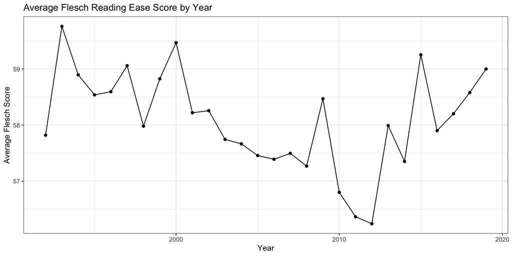

```r
library(dplyr)
library(ggplot2)
result_df <- reticulate::py$average_complexity_by_year
# Create the line plot
ggplot(result_df, aes(x = year, y = average_flesch_score)) +
  geom_line() +
  geom_point() +  # Adds points for clarity
  labs(
    title = "Average Flesch Reading Ease Score by Year",
    x = "Year",
    y = "Average Flesch Score")+
  theme_bw()
```

## Readibility of Speeches Over Time

Here is how we can calculate average complexity over time:

```
Python
```

```python
from textstat import flesch_kincaid_grade
import scipy.stats as stats

# Load the dataset
file_path = "/Users/bgpopescu/Library/CloudStorage/Dropbox/john_cabot/teaching/text_analysis/week8/lecture8b/data/aggression_texts.csv"
aggression_texts = pd.read_csv(file_path)
# Calculate flesch_score
aggression_texts['flesch_score'] = aggression_texts['body'].apply(flesch_kincaid_grade)
# Group by 'year' and 'gender' and calculate mean and confidence intervals
def calculate_confidence_interval(series):
    n = len(series)
    mean = series.mean()
    sem = stats.sem(series)  # Standard error of the mean
    ci_range = stats.t.interval(0.95, df=n-1, loc=mean, scale=sem) if n > 1 else (mean, mean)
    return pd.Series({'mean': mean, 'ci_lower': ci_range[0], 'ci_upper': ci_range[1]})

average_complexity_with_ci = (
    aggression_texts.groupby(['year', 'gender'])['flesch_score']
    .apply(calculate_confidence_interval)
    .reset_index()
)
## Group by the 'year' column and calculate the average Flesch Reading Ease score
# Pivot the DataFrame
df_transposed = average_complexity_with_ci.pivot(index=["year", "gender"], columns="level_2", values="flesch_score").reset_index()
```

**See code**

```
R
```

[figure not shown]

```r
library(dplyr)
library(broom)
result_df <- reticulate::py$df_transposed

# Create the line plot
ggplot(result_df, aes(x = year, y = mean, group = gender, color=gender)) +
  geom_line() +
  geom_point() +  # Adds points for clarity
    geom_ribbon(
    aes(ymin = ci_lower, ymax = ci_upper, fill = gender),
    alpha = 0.2,  # Transparency for the confidence interval
    color = NA     # Removes outline of the ribbon
  ) +
  labs(
    title = "Average Flesch Reading Ease Score by Year",
    x = "Year",
    y = "Average Flesch Score")+
  theme_bw()+
    scale_x_continuous(
    breaks = seq(min(result_df$year), max(result_df$year), by = 2))
```

## Readibility of Speeches Over Time

Here is how it compares to the original

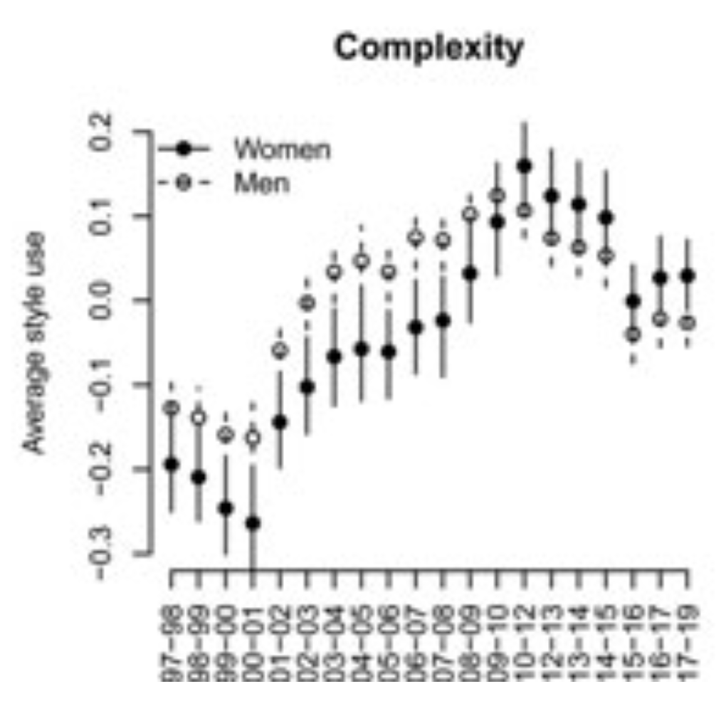

**See code**

```
R
```

[figure not shown]

```r
library(dplyr)
library(broom)
result_df <- reticulate::py$df_transposed
ggplot(result_df, aes(x = year, y = mean, group = gender, color=gender)) +
  geom_line() +
  geom_point() +  # Adds points for clarity
    geom_ribbon(
    aes(ymin = ci_lower, ymax = ci_upper, fill = gender),
    alpha = 0.2,  # Transparency for the confidence interval
    color = NA     # Removes outline of the ribbon
  ) +
  labs(
    title = "Average Flesch Reading Ease Score by Year",
    x = "Year",
    y = "Average Flesch Score")+
  theme_bw()+
    scale_x_continuous(
    breaks = seq(min(result_df$year), max(result_df$year), by = 2))
```

## Readibility of Speeches Over Time

Here are some interesting insights

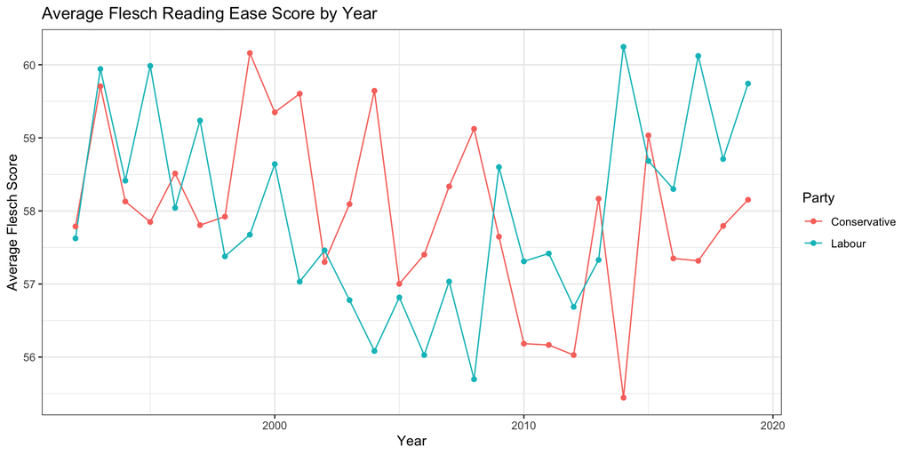

## Readibility of Speeches Over Time

What if we calculate language complexity of different politicians?

| name | average_flesch_score | speech_count |
| --- | --- | --- |
| Mr Roger Casale | 17.874 | 5 |
| Mr James Molyneaux | 21.24 | 5 |
| Martin Salter | 25.099 | 10 |
| Mr Jerry Wiggin | 27.156667 | 3 |
| Mr Peter Hardy | 27.277143 | 7 |
| Michael Dugher | 29.353333 | 3 |
| Mohammad Sarwar | 31.89 | 2 |
| Helen Southworth | 32.3725 | 4 |
| Mr Tom King | 32.726667 | 3 |
| Helen Hayes | 33.24 | 2 |

Let us look at one example of speech from the top candidate with at least two speeches:

[output not shown]

| name | average_flesch_score | speech_count |
| --- | --- | --- |
| Mr Irvine Patnick | 98.72 | 2 |
| Alan Campbell | 88.013333 | 3 |
| James Berry | 85.03 | 2 |
| Mr Jamie Cann | 84.68 | 2 |
| Mr Edward Heath | 83.84 | 4 |
| Mr David Ashby | 83.456667 | 3 |
| Ms Candy Atherton | 83.006667 | 3 |
| Mr Andy King | 82.29 | 2 |
| Dr Rhodes Boyson | 82.04 | 2 |
| Mr Piers Merchant | 81.85 | 8 |

Let us look at one example of speech from the top candidate with at least two speeches:

```
It's being so cheerful keeps you going.
```

## Readibility of Speeches Over Time

What if we calculate language complexity of different politicians?

| name | average_flesch_score | speech_count |
| --- | --- | --- |
| Mr Roger Casale | 17.874 | 5 |
| Mr James Molyneaux | 21.24 | 5 |
| Martin Salter | 25.099 | 10 |
| Mr Jerry Wiggin | 27.156667 | 3 |
| Mr Peter Hardy | 27.277143 | 7 |
| Michael Dugher | 29.353333 | 3 |
| Mohammad Sarwar | 31.89 | 2 |
| Helen Southworth | 32.3725 | 4 |
| Mr Tom King | 32.726667 | 3 |
| Helen Hayes | 33.24 | 2 |

Let us look at one example of speech from the top candidate with at least two speeches:

```
I am delighted to contribute briefly to the debate, although I am sorry that I am unable to be in my constituency of Wimbledon with the hundreds of thousands of British tennis fans who are celebrating the outstanding victory of Mr. Tim Henman. We all send our congratulations to him, and wish him wel…
```

| name | average_flesch_score | speech_count |
| --- | --- | --- |
| Mr Irvine Patnick | 98.72 | 2 |
| Alan Campbell | 88.013333 | 3 |
| James Berry | 85.03 | 2 |
| Mr Jamie Cann | 84.68 | 2 |
| Mr Edward Heath | 83.84 | 4 |
| Mr David Ashby | 83.456667 | 3 |
| Ms Candy Atherton | 83.006667 | 3 |
| Mr Andy King | 82.29 | 2 |
| Dr Rhodes Boyson | 82.04 | 2 |
| Mr Piers Merchant | 81.85 | 8 |

Let us look at one example of speech from the top candidate with at least two speeches:

```
He is in the Strangers' Gallery.
```

## Conclusion

**Complexity Analysis**:

- Metrics like Flesch Reading Ease assess readability, offering insights into text difficulty and audience targeting.
- Speech analysis tracks readability trends and politician-specific language complexity.
- Quantitative techniques uncover insights into text difficulty and audience alignment.
- Lexical diversity varies with text length, influencing complexity measurements.